# RNODE

Daniel YM Nakamura, Ward Wheeler, Taran Grant

November 13, 2024

# 1. Preamble

Tutorial to demonstrate the main functions available in the R package RNODE. This tutorial is organized in two sections related to preprocessing and post-processing of phylogenetic trees.

```r
# Load the package
library(ggplot2)
library(RNODE)
```

# 2. Preprocessing analyses

## 2.1 prepUnaligned: Unaligned sequence preprocessing

## 2.2 prepInvariant: Creates TNT or Nexus alignments with and without invariant sites

# 3. Post-processing analyses

## 3.1 compareNodes

First, we can demonstrate this function using two simulated trees with the same composition of terminals but different topologies. Notice that *composition = T* will show the composition of each clade in the output dataframe.

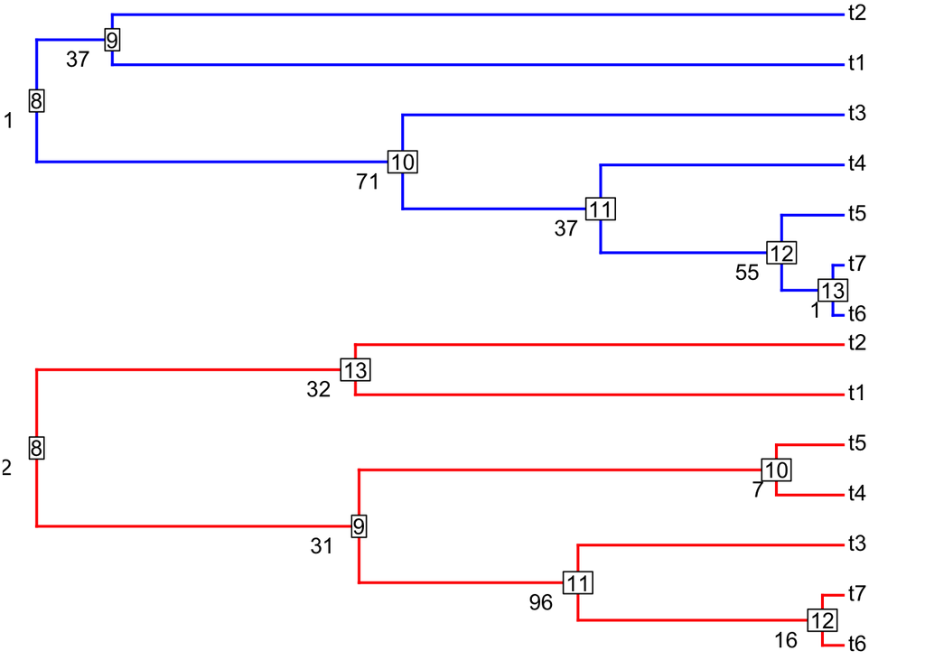

```r
# Simulate two trees
set.seed(44)
a = pbtree(n=7) # initial tree a
node_labels = sample(1:100, a$Nnode, replace = TRUE) # generate random node labels as integers to tree a
a$node.label = node_labels # add the node labels to tree a
set.seed(88)
b = pbtree(n=7) # initial tree b
node_labels = sample(1:100, b$Nnode, replace = TRUE) # Generate random node labels as integers to tree a
b$node.label = node_labels # Set the node labels to tree b

# Visualize trees
layout(c(1,2))
plotTree(ladderize(a, right = T),node.numbers=T, color="blue")
nodelabels(a$node.label,
           adj=c(1.9, 1.7), # horizontal and vertical position
           frame="none")
plotTree(ladderize(b, right = T),node.numbers=T, color="red")
nodelabels(b$node.label,
           adj=c(2, 1.7), # horizontal and vertical position
           frame="none")
```

```r
# Run compareNodes
compareNodes(tree1=a, tree2=b, composition=T)
```

```
## All required parameters provided.
```

```
## [1] ""
## [1] "Tree comparisons done!"
## [1] "Number of shared clades:  4"
## [1] "Support of shared clades in tree 1: 1–71 (45)"
## [1] "Support of shared clades in tree 2: 16–92 (42.75)"
## [1] "Spearman's test: RHO =  0.632455532033676 ; P-value =  0.367544467966324"
```

```
##   Node_Tree_1 Node_Tree_2 Support_Tree_1 Support_Tree_2
## 1           8           8             71             92
## 2           9          13             37             32
## 3          10           9             71             31
## 4          13          12              1             16
##                  Composition_Tree_1                Composition_Tree_2
## 1 (((((t6,t7),t5),t4),t3),(t1,t2)); ((((t6,t7),t3),(t4,t5)),(t1,t2));
## 2                          (t1,t2);                          (t1,t2);
## 3           ((((t6,t7),t5),t4),t3);           (((t6,t7),t3),(t4,t5));
## 4                          (t6,t7);                          (t6,t7);
```

Second, we can use **compareNodes** to compare two empirical trees in .nwk format estimated in TNT (datasets from Ruane et al. 2015). One tree was estimated with Sanger-based data, whereas the other one was estimated with AHE data. Polytomous nodes and input trees with different taxon samples are accepted but names of corresponding leaves should be equal in the input trees.

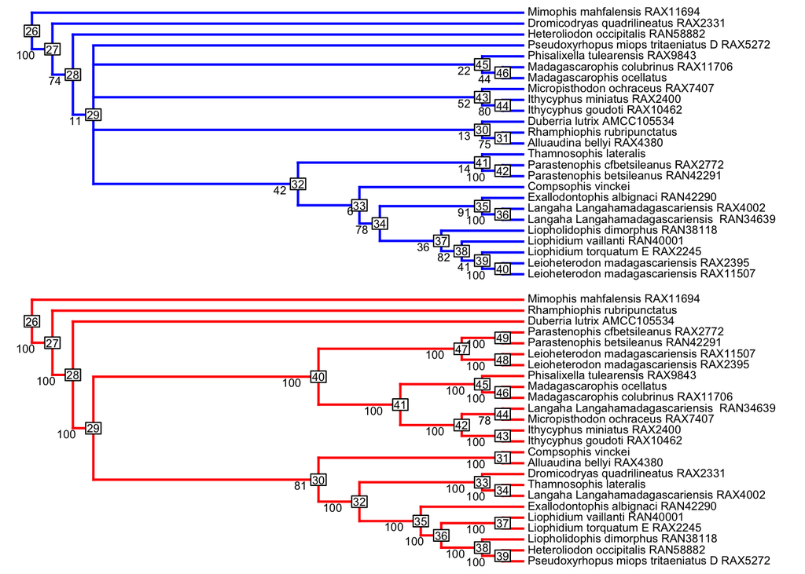

```r
# Load trees
Sanger = read.tree("../testdata/Ruane2015_Sanger.tre")
AHE = read.tree("../testdata/Ruane2015_AHE.tre")

# Visualize trees
layout(c(1,2))
plotTree(ladderize(Sanger, right = T),node.numbers=T, color="blue", fsize= 0.6)
nodelabels(Sanger$node.label,
           adj=c(1.9, 1.2), # horizontal and vertical position
           frame="none",
           cex=0.6)
plotTree(ladderize(AHE, right = T),node.numbers=T, color="red", fsize=0.6)
nodelabels(AHE$node.label,
           adj=c(1.9, 1.2), # horizontal and vertical position
           frame="none",
           cex=0.6)
```

```r
# Run compareNodes
compareNodes(tree1=Sanger, tree2=AHE, composition=F)
```

```
## All required parameters provided.
```

```
## [1] ""
## [1] "Tree comparisons done!"
## [1] "Number of shared clades:  7"
## [1] "Support of shared clades in tree 1: 22–100 (74.33)"
## [1] "Support of shared clades in tree 2: 100–100 (100)"
## [1] "Spearman's test: RHO =  NA ; P-value =  NA"
```

```
##   Node_Tree_1 Node_Tree_2 Support_Tree_1 Support_Tree_2
## 1          26          26
## 2          27          27            100            100
## 3          40          48            100            100
## 4          42          49            100            100
## 5          44          43             80            100
## 6          45          45             22            100
## 7          46          46             44            100
```

```r
# Alternatively, trees can be saved in PDF:
# compareNodes(tree1=Sanger, tree2=AHE, composition=F, plotTrees=T, width=8, height=8, fsize=0.6, adj=c(1.9,1.2), cex=0.6)
```

Third, besides Sanger vs AHE phylogenetic trees, **compareNodes** may be useful to compare trees across optimality criteria (e.g. parsimony vs maximum likelihood), character sampling (e.g. only-molecular vs molecular+phenomic analyses), and taxon sampling (e.g. only-extant vs extant and extinct taxa). For instance, we can plot the relationship between molecular and total evidence trees analyzed in IQ-TREE by Whitcher et al. (2024).

```r
# Load trees
MOL = read.tree("../testdata/Whitcher2024_ML_MOL.contree")
TE = read.tree("../testdata/Whitcher2024_ML_TE.contree")

# Run compareNodes
df = compareNodes(tree1=MOL, tree2=TE)
```

```
## All required parameters provided.
```

```
## [1] ""
## [1] "Tree comparisons done!"
## [1] "Number of shared clades:  237"
## [1] "Support of shared clades in tree 1: 41–100 (98.69)"
## [1] "Support of shared clades in tree 2: 40–100 (98.19)"
## [1] "Spearman's test: RHO =  0.728609813226939 ; P-value =  2.47640730658916e-40"
```

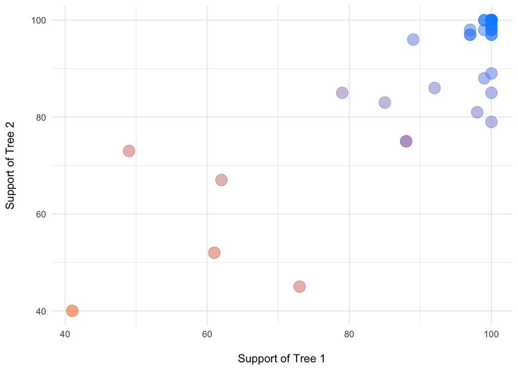

```r
# Plot the relationship of support between trees
df = df[-1,]
df$pc = predict(prcomp(~as.numeric(Support_Tree_1)+as.numeric(Support_Tree_2), df))[,1]
ggplot(df, aes(as.numeric(Support_Tree_1), as.numeric(Support_Tree_2), color=pc)) +
  geom_point(size = 5, show.legend = F, alpha=.5) +
  scale_color_gradient(low = "#0091ff", high = "#f0650e")+
  theme_minimal() +
  labs(x="\nSupport of Tree 1",
       y="Support of Tree 2\n")
```

As expected, there is a denser concentration of shared clades with higher values of support, whereas only a few poorly supported clades are shared by both trees.

## 3.2 uniqueNodes

In contrast to **compareNodes**, the list of descendants and support values of unique clades from each tree can be assessed using **uniqueNodes**.

## 3.3 pairwiseTopologies: Creates a pairwise matrix of topological distances; plot using heat map

## 3.4 consensusLabels: Insert branch lengths from a random MPT and support values in the strict consensus tree

## 3.5 iaTNT: Run a TNT analysis for each implied alignment derived from each MPT

# 4. References

Ruane, S., Raxworthy, C. J., Lemmon, A. R., Lemmon, E. M., & Burbrink, F. T. (2015). Comparing species tree estimation with large anchored phylogenomic and small Sanger-sequenced molecular datasets: an empirical study on Malagasy pseudoxyrhophiine snakes. BMC Evolutionary Biology, 15, 1-14.